# WGCNA UN

WGCNA analysis of UN gene expression in B. rapa RILs.

Lets start with some notes on what WGCNA is doing. (For more details, see [Zhang and Horvath, 2005](http://www.degruyter.com/view/j/sagmb.2005.4.1/sagmb.2005.4.1.1128/sagmb.2005.4.1.1128.xml;jsessionid=9F14E37B32BBAEB8DD0286D168168E7F) )

1. A correlation coefficient is calculated between all gene pairs.
2. This is converted to an adjacency matrix. Unlike typical adjacency matrices (which have values of 0, meaning not connected, or 1, meaning connected, based on some hard threshold) here the adjacency matrix can take any value from 0 to 1. Thus there is a soft threshold and the connectivity in the adjacency matrix is weighted by the correlations. Zhang and Horvath discuss different ways to relate the correlation matrix to the adjacency matrix, the default in WGCNA, and what I use, is a power function where the adjacency represent the correlation coefficient raised to some power $\beta$.
3. The power, $\beta$, is chosen such that the (weighted) connectivity shows a power law topology i.e. R2 of log10(p(k)) ~ log10(k) is > 0.9
4. Once an adjacency matrix is calculated the the similarity of nodes in the matrix is calculated using a topological overlap matrix (TOM). See Zhang and Horvath, 2005, for details. But basically a two nodes have a high TOM if they are connected to each other and to a similar set of other nodes.
5. To define modules genes are hiearchicaly clustered based on their distance (1-TOM) and a dynamic method is used to define cutoffs from this tree and the dissimilarity matrix. For more info see [here](https://labs.genetics.ucla.edu/horvath/htdocs/CoexpressionNetwork/BranchCutting/)
6. I tshould be noted that Zhang and Horvath provide formula to generalize most network calcualtions (i.e. connectivity, etc) from a 0,1 adjacency matrix to a 0-1 adjacency matrix.

```r
library(tidyverse)
library(WGCNA)
library(ggplot2)
library(edgeR)
library(magrittr)
library(gplots)
options(stringsAsFactors = FALSE)
```

Get data

```r
#box_load(162362592785)
load("../output/Voom_UN.Rdata")
annotation  <- read.csv("../input/Brapa_V1.5_annotated.csv")
```

```r
RIL.coefs.UN <- grep("RIL",colnames(coef(voom.fit.UN)))
RIL.pvals.UN <- topTable(voom.fit.UN,coef = RIL.coefs.UN,number = Inf)
sum(RIL.pvals.UN$adj.P.Val<0.01)
```

```
[1] 21147
```

```r
sum(RIL.pvals.UN$adj.P.Val<10e-05)
```

```
[1] 16116
```

So lots of genes are highly significant

Start by taking the top 10000

```r
genes.of.interest.UN <- row.names(RIL.pvals.UN)[1:10000]
expr.data.UN <- voom.fit.UN$coefficients[genes.of.interest.UN,]
dim(expr.data.UN)
```

```
[1] 10000   122
```

```r
head(expr.data.UN[,1:6])
```

```
          (Intercept) pdata.UN$RILRIL_103 pdata.UN$RILRIL_104 pdata.UN$RILRIL_113
Bra016271    8.771674          0.08916878          -7.2838361          -6.0361161
Bra038030    5.659462         -4.47691551          -4.4449358           0.1945122
Bra040132    4.799727          0.04230768          -5.6976648          -7.2323991
Bra017243    4.657314         -7.66966615          -6.3296197           0.5528568
Bra032770    6.460401         -7.28553000          -0.6852021          -6.2687290
Bra040221    5.445683         -0.12913160          -3.8066220          -5.5774633
          pdata.UN$RILRIL_115 pdata.UN$RILRIL_12
Bra016271          0.08846749        -6.35945387
Bra038030         -4.76037666        -7.26543168
Bra040132         -6.35361416         0.17549396
Bra017243         -7.82442643        -8.58950864
Bra032770         -0.27696341         0.03789648
Bra040221         -5.30085356         0.10217126
```

```r
expr.data.UN[,-1] <- expr.data.UN[,-1] + expr.data.UN[,1] # add the intercept to the coefficients
colnames(expr.data.UN) <- sub("pdata.UN$RIL","",colnames(expr.data.UN),fixed=TRUE)
colnames(expr.data.UN)[1] <- "RIL_1"
head(expr.data.UN[,1:6])
```

```
             RIL_1    RIL_103   RIL_104    RIL_113    RIL_115    RIL_12
Bra016271 8.771674  8.8608428  1.487838  2.7355580  8.8601416  2.412220
Bra038030 5.659462  1.1825469  1.214527  5.8539746  0.8990858 -1.605969
Bra040132 4.799727  4.8420345 -0.897938 -2.4326723 -1.5538874  4.975221
Bra017243 4.657314 -3.0123519 -1.672305  5.2101710 -3.1671122 -3.932194
Bra032770 6.460401 -0.8251288  5.775199  0.1916722  6.1834378  6.498298
Bra040221 5.445683  5.3165516  1.639061 -0.1317801  0.1448297  5.547854
```

Get Rob’s Data; remove STP Blup and other un-needed columns

```r
blups2011 <- read.csv("../input/Brapa2011BayesHeight_blups.csv",row.names = 1)
blups2012 <- read.csv("../input/Brapa2012BayesHeight_blups.csv", row.names = 1)
blups2011$Line %<>% paste("RIL",.,sep="_")
blups2012$Line %<>% paste("RIL",.,sep="_")
blups2011 %<>% subset(select=!grepl("V1|individual|blk|trt|treat|STP",colnames(.))) %>%
  rename(UNiD=UNInflect_DD,UNd=UNduration) %>%
  select(starts_with("Line"),starts_with("UN"),-matches("Inflect.*_size"))
blups2012 %<>% subset(select=!grepl("V1|individual|blk|trt|treat|STP",colnames(.))) %>%
  rename(UNiD=UNInflection_DD,UNd=UNduration) %>%
    select(starts_with("Line"),starts_with("UN"),-matches("Inflect.*_size"))
head(blups2011)
```

|  | Line | UNr | UNHmax | UNiD | UNd |
| --- | --- | --- | --- | --- | --- |
| 1 | RIL_1 | 0.01538042 | 45.33279 | 637.4364 | 891.0950 |
| 2 | RIL_2 | 0.01688921 | 52.52927 | 606.4137 | 847.8459 |
| 3 | RIL_7 | 0.01498168 | 50.49147 | 617.0949 | 886.2632 |
| 4 | RIL_9 | 0.01403688 | 37.52531 | 626.9736 | 887.4991 |
| 5 | RIL_12 | 0.01561517 | 29.25045 | 596.8828 | 873.0373 |
| 6 | RIL_15 | 0.01434298 | 57.08635 | 601.5191 | 869.1307 |

```r
head(blups2012)
```

|  | Line | UNr | UNHmax | UNiD | UNd |
| --- | --- | --- | --- | --- | --- |
| 1 | RIL_1 | 0.01265305 | 40.07475 | 659.1968 | 944.3922 |
| 2 | RIL_2 | 0.01312970 | 49.99002 | 661.9006 | 917.1550 |
| 3 | RIL_7 | 0.01368674 | 37.62779 | 516.3685 | 761.0105 |
| 4 | RIL_9 | 0.01339133 | 29.83789 | 545.0483 | 800.6085 |
| 5 | RIL_12 | 0.01447632 | 19.86868 | 516.6281 | 762.5616 |
| 6 | RIL_15 | 0.01324382 | 47.85415 | 616.4516 | 876.2526 |

Have decided to use 2011 and 2012 BLUPs but UN only…

```r
blups.UN <- merge(blups2011,blups2012,by="Line",suffixes = c("11","12")) %>%
  select(starts_with("Line"),starts_with("UN"),-matches("Inflect.*_size"))
head(blups.UN)
```

|  | Line | UNr11 | UNHmax11 | UNiD11 | UNd11 | UNr12 | UNHmax12 | UNiD12 | UNd12 |
| --- | --- | --- | --- | --- | --- | --- | --- | --- | --- |
| 1 | RIL_1 | 0.01538042 | 45.33279 | 637.4364 | 891.0950 | 0.01265305 | 40.07475 | 659.1968 | 944.3922 |
| 2 | RIL_103 | 0.01741061 | 57.40812 | 580.0306 | 814.0468 | 0.01411398 | 46.96119 | 617.6269 | 870.6890 |
| 3 | RIL_115 | 0.01613474 | 34.06731 | 597.6579 | 852.6048 | 0.01350071 | 26.29595 | 652.5562 | 910.2024 |
| 4 | RIL_12 | 0.01561517 | 29.25045 | 596.8828 | 873.0373 | 0.01447632 | 19.86868 | 516.6281 | 762.5616 |
| 5 | RIL_124 | 0.01435077 | 45.69290 | 663.1160 | 925.7309 | 0.01195275 | 44.69516 | 695.4424 | 966.1398 |
| 6 | RIL_131 | 0.01488750 | 39.65665 | 561.9340 | 829.9640 | 0.01375755 | 27.99045 | 487.2746 | 750.1288 |

## WGCNA

### UN

transform

```r
head(expr.data.UN[,1:6])
```

```
             RIL_1    RIL_103   RIL_104    RIL_113    RIL_115    RIL_12
Bra016271 8.771674  8.8608428  1.487838  2.7355580  8.8601416  2.412220
Bra038030 5.659462  1.1825469  1.214527  5.8539746  0.8990858 -1.605969
Bra040132 4.799727  4.8420345 -0.897938 -2.4326723 -1.5538874  4.975221
Bra017243 4.657314 -3.0123519 -1.672305  5.2101710 -3.1671122 -3.932194
Bra032770 6.460401 -0.8251288  5.775199  0.1916722  6.1834378  6.498298
Bra040221 5.445683  5.3165516  1.639061 -0.1317801  0.1448297  5.547854
```

```r
expr.data.UN.t <- t(expr.data.UN)
head(expr.data.UN.t[,1:6])
```

```
        Bra016271  Bra038030 Bra040132 Bra017243  Bra032770  Bra040221
RIL_1    8.771674  5.6594624  4.799727  4.657314  6.4604012  5.4456832
RIL_103  8.860843  1.1825469  4.842034 -3.012352 -0.8251288  5.3165516
RIL_104  1.487838  1.2145267 -0.897938 -1.672305  5.7751991  1.6390613
RIL_113  2.735558  5.8539746 -2.432672  5.210171  0.1916722 -0.1317801
RIL_115  8.860142  0.8990858 -1.553887 -3.167112  6.1834378  0.1448297
RIL_12   2.412220 -1.6059693  4.975221 -3.932194  6.4982977  5.5478545
```

check sample quality

```r
gag.UN <- goodSamplesGenes(expr.data.UN.t, verbose = 3)
```

```
 Flagging genes and samples with too many missing values...
  ..step 1
```

```r
gag.UN$allOK
```

```
[1] TRUE
```

cluster samples to look for outliers

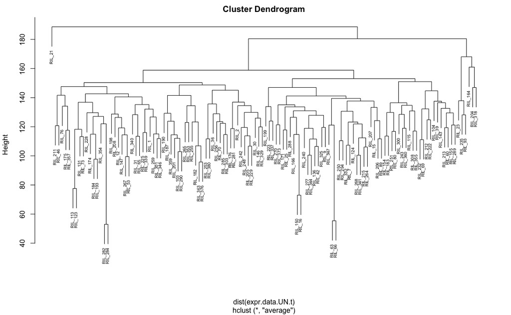

```r
sampleTREE.UN <- hclust(dist(expr.data.UN.t), method = "average")
plot(sampleTREE.UN,cex=.6)
```

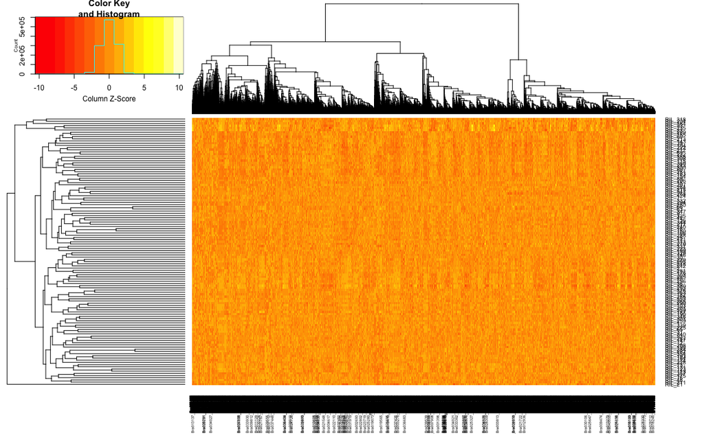

```r
heatmap.2(expr.data.UN.t,Rowv=as.dendrogram(sampleTREE.UN), scale="col", trace="none")
```

So a few samples are different but they don’t seem crazy different; leave them in for now.

Soft thresholding

```r
powers <- c(c(1:10), seq(from = 12, to=20, by=2))
sft <- pickSoftThreshold(expr.data.UN.t, powerVector = powers, verbose = 5,networkType = "signed hybrid")
```

```
pickSoftThreshold: will use block size 4473.
 pickSoftThreshold: calculating connectivity for given powers...
   ..working on genes 1 through 4473 of 10000
```

```
executing %dopar% sequentially: no parallel backend registered
```

```
   ..working on genes 4474 through 8946 of 10000
   ..working on genes 8947 through 10000 of 10000
```

| Power | SFT.R.sq | slope | truncated.R.sq | mean.k. | median.k. | max.k. |
| --- | --- | --- | --- | --- | --- | --- |
| 1 | 0.224 | -0.603 | 0.623 | 997.00 | 903.0000 | 2110.0 |
| 2 | 0.899 | -1.160 | 0.934 | 352.00 | 257.0000 | 1190.0 |
| 3 | 0.951 | -1.290 | 0.955 | 167.00 | 91.3000 | 812.0 |
| 4 | 0.961 | -1.320 | 0.963 | 93.90 | 39.5000 | 602.0 |
| 5 | 0.948 | -1.340 | 0.949 | 58.70 | 20.1000 | 468.0 |
| 6 | 0.943 | -1.350 | 0.943 | 39.40 | 11.0000 | 376.0 |
| 7 | 0.948 | -1.350 | 0.948 | 27.90 | 6.4800 | 308.0 |
| 8 | 0.951 | -1.350 | 0.952 | 20.50 | 4.0500 | 257.0 |
| 9 | 0.946 | -1.350 | 0.944 | 15.50 | 2.6400 | 217.0 |
| 10 | 0.956 | -1.330 | 0.954 | 12.00 | 1.7600 | 186.0 |

[output cut: 5 more lines]

```r
sizeGrWindow(9, 5)
par(mfrow = c(1,2))
cex1 <- 0.9
# Scale-free topology fit index as a function of the soft-thresholding power
plot(sft$fitIndices[,1], -sign(sft$fitIndices[,3])*sft$fitIndices[,2],
     xlab="Soft Threshold (power)",ylab="Scale Free Topology Model Fit,signed R^2",type="n",
     main = paste("Scale independence"))
text(sft$fitIndices[,1], -sign(sft$fitIndices[,3])*sft$fitIndices[,2],
     labels=powers,cex=cex1,col="red")
```

```r
# this line corresponds to using an R^2 cut-off of h
abline(h=0.90,col="red")
# Mean connectivity as a function of the soft-thresholding power
plot(sft$fitIndices[,1], sft$fitIndices[,5],
     xlab="Soft Threshold (power)",ylab="Mean Connectivity", type="n",
     main = paste("Mean connectivity"))
```

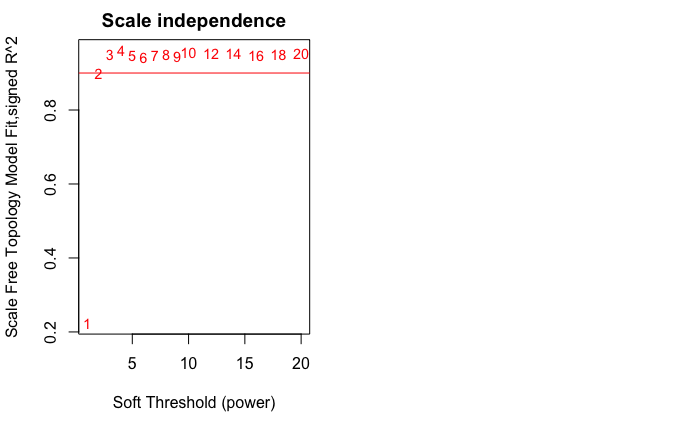

```r
text(sft$fitIndices[,1], sft$fitIndices[,5], labels=powers, cex=cex1,col="red")
```

choose 3

```r
softPower <- 3
adjacency <- adjacency(expr.data.UN.t, power = softPower, type = "signed hybrid")
# Turn adjacency into topological overlap
TOM <- TOMsimilarity(adjacency);
```

```
..connectivity..
..matrix multiplication (system BLAS)..
..normalization..
..done.
```

```r
dissTOM <- 1-TOM
```

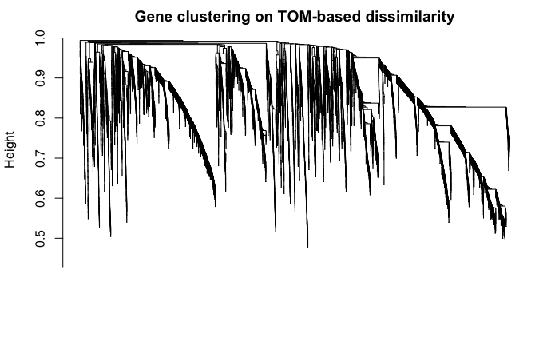

```r
# Call the hierarchical clustering function
geneTree <- hclust(as.dist(dissTOM), method = "average")
# Plot the resulting clustering tree (dendrogram)
sizeGrWindow(12,9)
plot(geneTree, xlab="", sub="", main = "Gene clustering on TOM-based dissimilarity",
     labels = FALSE, hang = 0.04)
```

define modules

```r
# We like large modules, so we set the minimum module size relatively high:
minModuleSize <- 30;
# Module identification using dynamic tree cut:
dynamicMods <- cutreeDynamic(dendro = geneTree, distM = dissTOM,
                             deepSplit <- 2, pamRespectsDendro = FALSE,
                             minClusterSize = minModuleSize);
```

```
 ..done.
```

```r
table(dynamicMods)
```

```
dynamicMods
   1    2    3    4    5    6    7    8    9   10   11   12   13   14   15   16
2021 1521  667  583  541  386  293  206  204  198  162  155  147  146  145  144
  17   18   19   20   21   22   23   24   25   26   27   28   29   30   31   32
 143  139  134  131  114  113  109   97   95   93   91   91   85   79   72   59
  33   34   35   36   37   38   39   40   41   42   43   44   45   46   47   48
  58   56   55   49   47   45   43   42   41   40   40   40   39   39   38   37
  49   50   51   52
  34   32   31   30
```

```r
# Convert numeric labels into colors
dynamicColors = labels2colors(dynamicMods)
table(dynamicColors)
```

```
dynamicColors
        bisque4           black            blue           brown          brown4
             38             293            1521             667              39
           cyan       darkgreen        darkgrey     darkmagenta  darkolivegreen
            146             113              97              56              58
     darkorange     darkorange2         darkred   darkslateblue   darkturquoise
             93              39             114              37             109
    floralwhite           green     greenyellow          grey60           ivory
             40             541             162             143              40
      lightcyan      lightcyan1      lightgreen lightsteelblue1     lightyellow
            144              40             139              41             134
        magenta   mediumpurple3    midnightblue          orange      orangered4
            204              42             145              95              43
  paleturquoise            pink           plum1           plum2          purple
             72             206              45              34             198
            red       royalblue     saddlebrown          salmon         salmon4
            386             131              85             147              30
        sienna3         skyblue        skyblue3       steelblue             tan
             55              91              47              79             155
       thistle1        thistle2       turquoise          violet           white
             31              32            2021              59              91
         yellow     yellowgreen
            583              49
```

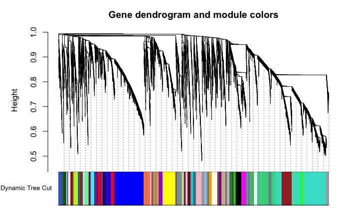

```r
# Plot the dendrogram and colors underneath
sizeGrWindow(8,6)
plotDendroAndColors(geneTree, dynamicColors, "Dynamic Tree Cut",
                    dendroLabels = FALSE, hang = 0.03,
                    addGuide = TRUE, guideHang = 0.05,
                    main = "Gene dendrogram and module colors")
```

merge similar modules

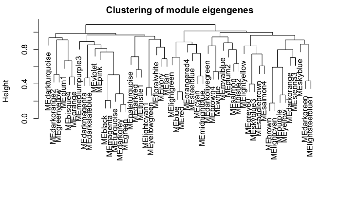

```r
# Calculate eigengenes
MEList <- moduleEigengenes(expr.data.UN.t, colors = dynamicColors)
MEs <- MEList$eigengenes
# Calculate dissimilarity of module eigengenes
MEDiss <- 1-cor(MEs);
# Cluster module eigengenes
METree <- hclust(as.dist(MEDiss), method = "average");
# Plot the result
sizeGrWindow(7, 6)
plot(METree, main = "Clustering of module eigengenes",
     xlab = "", sub = "")
```

merge with correlation > 0.8

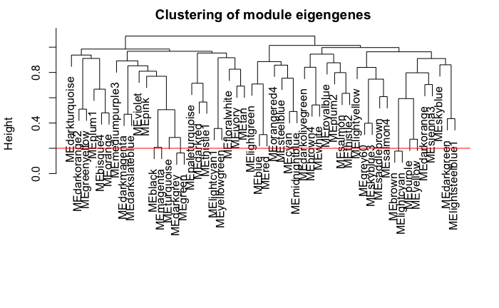

```r
MEDissThres = 0.2
# Plot the cut line into the dendrogram
plot(METree, main = "Clustering of module eigengenes",
     xlab = "", sub = "")
abline(h=MEDissThres, col = "red")
```

```r
# Call an automatic merging function
merge = mergeCloseModules(expr.data.UN.t, dynamicColors, cutHeight = MEDissThres, verbose = 3)
```

```
 mergeCloseModules: Merging modules whose distance is less than 0.2
   multiSetMEs: Calculating module MEs.
     Working on set 1 ...
     moduleEigengenes: Calculating 52 module eigengenes in given set.
   multiSetMEs: Calculating module MEs.
     Working on set 1 ...
     moduleEigengenes: Calculating 50 module eigengenes in given set.
   Calculating new MEs...
   multiSetMEs: Calculating module MEs.
     Working on set 1 ...
     moduleEigengenes: Calculating 50 module eigengenes in given set.
```

```r
# The merged module colors
mergedColors = merge$colors
# Eigengenes of the new merged modules:
mergedMEs = merge$newMEs
```

compare pre and post merge

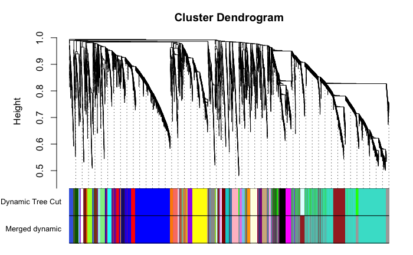

```r
sizeGrWindow(12, 9)
#pdf(file = "Plots/geneDendro-3.pdf", wi = 9, he = 6)
plotDendroAndColors(geneTree, cbind(dynamicColors, mergedColors),
                    c("Dynamic Tree Cut", "Merged dynamic"),
                    dendroLabels = FALSE, hang = 0.03,
                    addGuide = TRUE, guideHang = 0.05)
```

```r
#dev.off()
```

```r
# Rename to moduleColors
moduleColors = mergedColors
# Construct numerical labels corresponding to the colors
colorOrder = c("grey", standardColors(50));
moduleLabels = match(moduleColors, colorOrder)-1;
MEs = mergedMEs
table(merge$colors)
```

```
        bisque4           black            blue           brown          brown4
             38             293            1521             811              39
           cyan       darkgreen        darkgrey     darkmagenta  darkolivegreen
            146             113             638              56              58
     darkorange     darkorange2         darkred   darkslateblue   darkturquoise
             93              39             114              37             109
    floralwhite     greenyellow          grey60           ivory      lightcyan1
             40             162             143              40              40
     lightgreen lightsteelblue1     lightyellow         magenta   mediumpurple3
            139              41             134             204              42
   midnightblue          orange      orangered4   paleturquoise            pink
            145              95              43              72             206
          plum1           plum2          purple             red       royalblue
             45              34             198             386             131
    saddlebrown          salmon         salmon4         sienna3         skyblue
             85             147              30              55              91
       skyblue3       steelblue             tan        thistle1        thistle2
             47              79             155              31              32
      turquoise          violet           white          yellow     yellowgreen
           2021              59              91             583              49
```

```r
length(table(merge$colors))
```

```
[1] 50
```

```r
median(table(merge$colors))
```

```
[1] 91
```

```r
head(MEs)
```

|  | MEdarkturquoise | MEroyalblue | MEdarkorange2 | MEgreenyellow | MEplum1 | MEbisque4 | MEorange | MEmediumpurple3 | MEbrown | MEdarkgrey | MEturquoise | MEdarkmagenta | MEdarkslateblue | MEpink | MEviolet | MEblack | MEmagenta | MEpaleturquoise | MEdarkred | MEthistle1 | MElightcyan1 | MEyellowgreen | MEfloralwhite | MEivory | MEtan | MEskyblue | MEdarkgreen | MElightsteelblue1 | MElightgreen | … |
| --- | --- | --- | --- | --- | --- | --- | --- | --- | --- | --- | --- | --- | --- | --- | --- | --- | --- | --- | --- | --- | --- | --- | --- | --- | --- | --- | --- | --- | --- | --- |
| 1 | -0.10946134 | 0.11076526 | -0.09466035 | -0.09078331 | -0.02290192 | -0.13375851 | 0.02955794 | -0.02039907 | 0.02165880 | 0.03167984 | 0.05060017 | -0.10440873 | -0.098414486 | -0.11239540 | 0.11090251 | 0.061152155 | 0.01075597 | 0.09702839 | 0.08270291 | -0.06880387 | -0.10622587 | -0.05555577 | 0.10507580 | 0.09393829 | 0.12492648 | -0.12540428 | 0.12471935 | 0.11252384 | 0.18051857 | … |
| 2 | -0.09812739 | -0.03139994 | 0.09956483 | 0.08971814 | 0.08086269 | 0.08320402 | 0.07900311 | 0.03297917 | 0.05515722 | 0.12861012 | 0.15643611 | 0.10392982 | 0.049275416 | -0.13314164 | -0.05429828 | -0.001094512 | 0.02569433 | -0.10877784 | 0.09030576 | -0.10349462 | 0.07167806 | 0.07449990 | 0.09596312 | 0.10408453 | 0.11320517 | 0.01785686 | 0.10180016 | 0.11113818 | -0.01600263 | … |
| 3 | -0.02862548 | 0.12753899 | 0.10820491 | -0.06191428 | 0.10713873 | 0.09167252 | 0.06656814 | -0.07411038 | -0.08338866 | -0.06482480 | -0.17831827 | 0.14044428 | 0.108807859 | 0.04708788 | 0.08242164 | 0.086161225 | -0.02244248 | 0.15358142 | 0.08031039 | -0.05836539 | 0.08252449 | -0.04102568 | -0.06239884 | 0.09933155 | -0.01029693 | -0.10826465 | -0.05346043 | -0.04066251 | 0.10099411 | … |
| 4 | -0.04160735 | -0.10128081 | -0.09347397 | -0.11533203 | -0.11082370 | 0.02763607 | -0.14555458 | 0.10966665 | 0.06891831 | 0.03781103 | 0.10112030 | 0.06435735 | 0.093176504 | -0.14640218 | -0.08281108 | -0.044119522 | -0.02521756 | -0.10549014 | -0.10507480 | -0.08545406 | -0.13173627 | -0.11937279 | -0.11009527 | -0.12906520 | -0.10314883 | 0.07906995 | 0.13184405 | 0.09016382 | -0.11811841 | … |
| 5 | 0.08641094 | 0.11558657 | -0.08882880 | -0.07863761 | -0.11167213 | -0.05125664 | -0.13324894 | -0.07455847 | -0.08615459 | -0.12732856 | -0.18186808 | 0.11070238 | 0.001501158 | -0.10620917 | 0.02063929 | 0.002415041 | -0.05746651 | 0.14681329 | 0.10573861 | -0.07377138 | 0.07890335 | 0.09760817 | -0.07952442 | -0.11390334 | -0.09173135 | -0.09858798 | 0.12049647 | 0.12951202 | 0.10174250 | … |
| 6 | 0.10950964 | 0.13294756 | 0.10203578 | -0.08308081 | -0.13505667 | -0.11583528 | -0.13160553 | -0.08475282 | -0.02025714 | 0.02418190 | -0.01859692 | -0.07095040 | -0.117484469 | 0.09452768 | -0.08570131 | 0.043966674 | 0.08557556 | -0.08455629 | 0.07440607 | -0.08892758 | 0.06932473 | 0.10407953 | 0.08666821 | 0.08982628 | 0.11817966 | -0.14551717 | -0.08195820 | -0.08623628 | 0.07451211 | … |

```r
dim(MEs)
```

```
[1] 122  50
```

```r
dim(blups.UN)
```

```
[1] 121   9
```

```r
rownames(expr.data.UN.t)
```

```
  [1] "RIL_1"   "RIL_103" "RIL_104" "RIL_113" "RIL_115" "RIL_12"  "RIL_123"
  [8] "RIL_124" "RIL_131" "RIL_136" "RIL_143" "RIL_146" "RIL_147" "RIL_15"
 [15] "RIL_150" "RIL_154" "RIL_155" "RIL_16"  "RIL_164" "RIL_166" "RIL_171"
 [22] "RIL_174" "RIL_175" "RIL_176" "RIL_182" "RIL_183" "RIL_184" "RIL_187"
 [29] "RIL_190" "RIL_193" "RIL_198" "RIL_199" "RIL_2"   "RIL_201" "RIL_204"
 [36] "RIL_205" "RIL_206" "RIL_207" "RIL_208" "RIL_21"  "RIL_211" "RIL_212"
 [43] "RIL_213" "RIL_215" "RIL_222" "RIL_223" "RIL_225" "RIL_228" "RIL_229"
 [50] "RIL_23"  "RIL_232" "RIL_235" "RIL_240" "RIL_242" "RIL_243" "RIL_248"
 [57] "RIL_25"  "RIL_250" "RIL_251" "RIL_253" "RIL_255" "RIL_256" "RIL_259"
 [64] "RIL_264" "RIL_265" "RIL_267" "RIL_268" "RIL_270" "RIL_277" "RIL_281"
 [71] "RIL_282" "RIL_284" "RIL_285" "RIL_288" "RIL_289" "RIL_290" "RIL_294"
 [78] "RIL_30"  "RIL_300" "RIL_301" "RIL_303" "RIL_308" "RIL_31"  "RIL_318"
 [85] "RIL_325" "RIL_329" "RIL_332" "RIL_337" "RIL_339" "RIL_340" "RIL_341"
 [92] "RIL_344" "RIL_346" "RIL_347" "RIL_353" "RIL_354" "RIL_355" "RIL_357"
 [99] "RIL_359" "RIL_36"  "RIL_360" "RIL_363" "RIL_373" "RIL_376" "RIL_380"
[106] "RIL_39"  "RIL_42"  "RIL_46"  "RIL_53"  "RIL_60"  "RIL_63"  "RIL_65"
[113] "RIL_66"  "RIL_69"  "RIL_7"   "RIL_70"  "RIL_73"  "RIL_76"  "RIL_80"
[120] "RIL_89"  "RIL_9"   "RIL_93"
```

```r
rownames(MEs)
```

```
  [1] "1"   "2"   "3"   "4"   "5"   "6"   "7"   "8"   "9"   "10"  "11"  "12"  "13"
 [14] "14"  "15"  "16"  "17"  "18"  "19"  "20"  "21"  "22"  "23"  "24"  "25"  "26"
 [27] "27"  "28"  "29"  "30"  "31"  "32"  "33"  "34"  "35"  "36"  "37"  "38"  "39"
 [40] "40"  "41"  "42"  "43"  "44"  "45"  "46"  "47"  "48"  "49"  "50"  "51"  "52"
 [53] "53"  "54"  "55"  "56"  "57"  "58"  "59"  "60"  "61"  "62"  "63"  "64"  "65"
 [66] "66"  "67"  "68"  "69"  "70"  "71"  "72"  "73"  "74"  "75"  "76"  "77"  "78"
 [79] "79"  "80"  "81"  "82"  "83"  "84"  "85"  "86"  "87"  "88"  "89"  "90"  "91"
 [92] "92"  "93"  "94"  "95"  "96"  "97"  "98"  "99"  "100" "101" "102" "103" "104"
[105] "105" "106" "107" "108" "109" "110" "111" "112" "113" "114" "115" "116" "117"
[118] "118" "119" "120" "121" "122"
```

```r
rownames(MEs) <- rownames(expr.data.UN.t)
head(blups.UN)
```

|  | Line | UNr11 | UNHmax11 | UNiD11 | UNd11 | UNr12 | UNHmax12 | UNiD12 | UNd12 |
| --- | --- | --- | --- | --- | --- | --- | --- | --- | --- |
| 1 | RIL_1 | 0.01538042 | 45.33279 | 637.4364 | 891.0950 | 0.01265305 | 40.07475 | 659.1968 | 944.3922 |
| 2 | RIL_103 | 0.01741061 | 57.40812 | 580.0306 | 814.0468 | 0.01411398 | 46.96119 | 617.6269 | 870.6890 |
| 3 | RIL_115 | 0.01613474 | 34.06731 | 597.6579 | 852.6048 | 0.01350071 | 26.29595 | 652.5562 | 910.2024 |
| 4 | RIL_12 | 0.01561517 | 29.25045 | 596.8828 | 873.0373 | 0.01447632 | 19.86868 | 516.6281 | 762.5616 |
| 5 | RIL_124 | 0.01435077 | 45.69290 | 663.1160 | 925.7309 | 0.01195275 | 44.69516 | 695.4424 | 966.1398 |
| 6 | RIL_131 | 0.01488750 | 39.65665 | 561.9340 | 829.9640 | 0.01375755 | 27.99045 | 487.2746 | 750.1288 |

```r
ME.blups <- merge(blups.UN,MEs,by.x=1.,by.y=0)
head(ME.blups)
```

|  | Line | UNr11 | UNHmax11 | UNiD11 | UNd11 | UNr12 | UNHmax12 | UNiD12 | UNd12 | MEdarkturquoise | MEroyalblue | MEdarkorange2 | MEgreenyellow | MEplum1 | MEbisque4 | MEorange | MEmediumpurple3 | MEbrown | MEdarkgrey | MEturquoise | MEdarkmagenta | MEdarkslateblue | MEpink | MEviolet | MEblack | MEmagenta | MEpaleturquoise | MEdarkred | MEthistle1 | … |
| --- | --- | --- | --- | --- | --- | --- | --- | --- | --- | --- | --- | --- | --- | --- | --- | --- | --- | --- | --- | --- | --- | --- | --- | --- | --- | --- | --- | --- | --- | --- |
| 1 | RIL_1 | 0.01538042 | 45.33279 | 637.4364 | 891.0950 | 0.01265305 | 40.07475 | 659.1968 | 944.3922 | -0.10946134 | 0.11076526 | -0.09466035 | -0.09078331 | -0.02290192 | -0.13375851 | 0.02955794 | -0.02039907 | 0.02165880 | 0.03167984 | 0.05060017 | -0.10440873 | -0.098414486 | -0.11239540 | 0.110902510 | 0.061152155 | 0.010755965 | 0.09702839 | 0.08270291 | -0.06880387 | … |
| 2 | RIL_103 | 0.01741061 | 57.40812 | 580.0306 | 814.0468 | 0.01411398 | 46.96119 | 617.6269 | 870.6890 | -0.09812739 | -0.03139994 | 0.09956483 | 0.08971814 | 0.08086269 | 0.08320402 | 0.07900311 | 0.03297917 | 0.05515722 | 0.12861012 | 0.15643611 | 0.10392982 | 0.049275416 | -0.13314164 | -0.054298276 | -0.001094512 | 0.025694326 | -0.10877784 | 0.09030576 | -0.10349462 | … |
| 3 | RIL_115 | 0.01613474 | 34.06731 | 597.6579 | 852.6048 | 0.01350071 | 26.29595 | 652.5562 | 910.2024 | 0.08641094 | 0.11558657 | -0.08882880 | -0.07863761 | -0.11167213 | -0.05125664 | -0.13324894 | -0.07455847 | -0.08615459 | -0.12732856 | -0.18186808 | 0.11070238 | 0.001501158 | -0.10620917 | 0.020639294 | 0.002415041 | -0.057466514 | 0.14681329 | 0.10573861 | -0.07377138 | … |
| 4 | RIL_12 | 0.01561517 | 29.25045 | 596.8828 | 873.0373 | 0.01447632 | 19.86868 | 516.6281 | 762.5616 | 0.10950964 | 0.13294756 | 0.10203578 | -0.08308081 | -0.13505667 | -0.11583528 | -0.13160553 | -0.08475282 | -0.02025714 | 0.02418190 | -0.01859692 | -0.07095040 | -0.117484469 | 0.09452768 | -0.085701311 | 0.043966674 | 0.085575559 | -0.08455629 | 0.07440607 | -0.08892758 | … |
| 5 | RIL_124 | 0.01435077 | 45.69290 | 663.1160 | 925.7309 | 0.01195275 | 44.69516 | 695.4424 | 966.1398 | -0.08807011 | 0.07338637 | 0.09703610 | 0.11306634 | -0.08409589 | 0.09840015 | 0.07452152 | 0.11616136 | -0.04467512 | 0.05904689 | 0.04643403 | 0.10847883 | 0.079556780 | 0.06627845 | 0.005876234 | -0.055826864 | -0.004667133 | -0.08861028 | 0.03938156 | -0.09306848 | … |
| 6 | RIL_131 | 0.01488750 | 39.65665 | 561.9340 | 829.9640 | 0.01375755 | 27.99045 | 487.2746 | 750.1288 | 0.03144206 | -0.09173727 | -0.09425883 | -0.09422212 | 0.09444277 | -0.06377024 | 0.07263697 | 0.10386224 | 0.10547322 | 0.09986918 | 0.14435026 | -0.08662093 | 0.003424444 | -0.12744100 | -0.007726053 | -0.067740689 | -0.016041716 | -0.02917485 | -0.07654533 | 0.09881215 | … |

```r
blups.cor <- cor(select(ME.blups,starts_with("UN")),
                 select(ME.blups, starts_with("ME")))
range(blups.cor)
```

```
[1] -0.5937518  0.5768170
```

```r
blups.cor
```

```
         MEdarkturquoise MEroyalblue MEdarkorange2 MEgreenyellow     MEplum1
UNr11         0.05633284   0.2014031   -0.13301958   -0.08368324 -0.02895168
UNHmax11     -0.15600284  -0.1696224    0.22160847    0.27237612 -0.15980377
UNiD11       -0.15445948  -0.1816013    0.10290747    0.09652734 -0.15608035
UNd11        -0.08095945  -0.2201151    0.18993326    0.12199572 -0.17961812
UNr12         0.15690997   0.1001269   -0.03149390    0.07349787 -0.09967295
UNHmax12     -0.17798772  -0.1335870    0.10793901    0.14350248 -0.17148438
UNiD12       -0.09119076  -0.1674328   -0.04464388   -0.08067054 -0.22668319
UNd12        -0.12941698  -0.1823899   -0.04048194   -0.09929924 -0.18922322
           MEbisque4    MEorange MEmediumpurple3     MEbrown  MEdarkgrey
UNr11     0.02709167 -0.03088667      0.01310644 -0.05549281 -0.10811422
UNHmax11 -0.08867583 -0.20880103     -0.21519761 -0.19382455 -0.01223054
UNiD11   -0.02622391 -0.25447484     -0.07561067 -0.16143254 -0.07862737
UNd11    -0.06694436 -0.21972398     -0.05738862 -0.12681565 -0.04244747
UNr12     0.03067204  0.00698962      0.17642470  0.06158113  0.14168148
UNHmax12 -0.05398305 -0.23432269     -0.29193717 -0.34732105 -0.15179131
UNiD12   -0.04383733 -0.31874137     -0.29202703 -0.47274885 -0.30524209
UNd12    -0.04203595 -0.28724024     -0.30462230 -0.43433434 -0.31954421
         MEturquoise MEdarkmagenta MEdarkslateblue      MEpink     MEviolet
UNr11    -0.11761884   -0.08141754     -0.03436138 -0.14404606 -0.013223808
UNHmax11 -0.10508740    0.05886011      0.34714015 -0.01358788  0.064206078
UNiD11   -0.10462463    0.14118960      0.28861923  0.08398671 -0.161679868
UNd11    -0.05922096    0.18114550      0.29043673  0.09199077 -0.158694701
UNr12     0.10930891   -0.17020187     -0.46769829  0.21003069  0.019345950
UNHmax12 -0.25003514   -0.00334921      0.31117670 -0.11463562  0.002102611
UNiD12   -0.41420781    0.02473889      0.23900835 -0.18765569 -0.075056424
UNd12    -0.40128333    0.06067140      0.31047827 -0.23188556 -0.068511962
              MEblack   MEmagenta MEpaleturquoise   MEdarkred  MEthistle1
UNr11     0.012867051 -0.07932574     -0.06007608 -0.06115506 -0.25151818
UNHmax11  0.124143111 -0.03802176      0.01115997  0.07312140  0.02535277
UNiD11    0.021748548 -0.14242962      0.04876665 -0.03361702 -0.01401044
UNd11     0.001214289 -0.11913304      0.03147037  0.02131683  0.04668909
UNr12     0.002965096  0.25364309     -0.24968975 -0.13798913 -0.30211467
UNHmax12  0.075578760 -0.17086522      0.10680812  0.03756275 -0.06196605
UNiD12    0.002645095 -0.29187836      0.11172065 -0.05347108 -0.14675202
UNd12    -0.009671527 -0.32955946      0.15686578 -0.02439626 -0.06428696
         MElightcyan1 MEyellowgreen MEfloralwhite      MEivory      MEtan
UNr11     -0.02879189  -0.003419249    0.27203155  0.089209641 0.15292097
UNHmax11  -0.18655774  -0.398396251    0.22362407  0.036568080 0.23081321
UNiD11    -0.26782901  -0.349017549   -0.07776954 -0.002008174 0.06757480
```

[output cut: 35 more lines]

```
UNiD11        0.013477638  0.04829049  0.02548000 -0.32247700 -0.20701927
UNd11         0.007285885 -0.02408633 -0.02791284 -0.27290217 -0.16761942
UNr12         0.076860620  0.25696334  0.13095911  0.24494768  0.06592048
UNHmax12     -0.049089547  0.07328057 -0.05460900 -0.59375176 -0.47950254
UNiD12        0.045271908  0.20876146  0.06776774 -0.54076447 -0.22921336
UNd12         0.006744450  0.13381772  0.03770212 -0.53384249 -0.21416073
         MEdarkorange   MEsienna3      MEplum2     MEsalmon   MEthistle2
UNr11     -0.02143921  0.08360577 -0.001868237 -0.171760619 -0.303833879
UNHmax11  -0.13639459 -0.04433163 -0.212589848 -0.279316531 -0.274046986
UNiD11     0.12410151 -0.09805876 -0.093397480 -0.077933293  0.050380900
UNd11      0.13652860 -0.15129648 -0.114379770 -0.021689721  0.086969794
UNr12     -0.01671846  0.24955226  0.058222174 -0.005656349 -0.069148035
UNHmax12  -0.06512736  0.01925657 -0.228905550 -0.270233531 -0.242024307
UNiD12     0.03613718 -0.01395401 -0.142249732 -0.146332746 -0.001806667
UNd12      0.03323128 -0.06804294 -0.138669293 -0.131507675  0.012042293
```

```r
blups.cor.P <- corPvalueStudent(blups.cor,nrow(expr.data.UN.t)) %>%
  p.adjust() %>% #using "holm" method.  For relaxed stringency could use "fdr"
  matrix(nrow=nrow(blups.cor),
         dimnames = dimnames(blups.cor))
sum(blups.cor.P < 0.05)
```

```
[1] 35
```

```r
blups.cor.sig <- blups.cor
blups.cor.sig[blups.cor.P>0.05] <- NA
blups.cor.sig <- blups.cor.sig[,!apply(blups.cor.sig,2,function(x) all(is.na(x)))]
blups.cor.sig
```

```
            MEbrown MEturquoise MEdarkslateblue MEyellowgreen MElightgreen
UNr11            NA          NA              NA            NA           NA
UNHmax11         NA          NA       0.3471402    -0.3983963           NA
UNiD11           NA          NA              NA    -0.3490175           NA
UNd11            NA          NA              NA            NA           NA
UNr12            NA          NA      -0.4676983     0.4368051           NA
UNHmax12 -0.3473210          NA              NA    -0.4023238           NA
UNiD12   -0.4727488  -0.4142078              NA            NA    0.3532366
UNd12    -0.4343343  -0.4012833              NA    -0.3635991    0.3762556
            MEblue MEsteelblue    MEcyan MEmidnightblue   MEpurple   MEyellow
UNr11           NA          NA        NA             NA         NA         NA
UNHmax11        NA          NA 0.4756141      0.3526245 -0.5086908 -0.5233454
UNiD11          NA   0.3424031        NA             NA         NA         NA
UNd11           NA          NA        NA             NA         NA         NA
UNr12           NA  -0.3460067        NA             NA         NA         NA
UNHmax12 0.3418758   0.3540780 0.5768170      0.5125199 -0.5937518 -0.4795025
UNiD12   0.4768825          NA 0.5225850      0.5197314 -0.5407645         NA
UNd12    0.4730140   0.3859504 0.5143309      0.5251662 -0.5338425         NA
```

```r
p.asterisk <- ifelse(blups.cor.P < 0.05, "*","")
```

plot it

```r
# Will display correlations and their p-values
par(mar = c(8, 8, 3, 3));
# Display the correlation values within a heatmap plot
labeledHeatmap(Matrix = blups.cor,
               yLabels = names(blups.UN)[-1],
               xLabels = names(MEs) %>% str_replace("^ME",""),
               xSymbols = names(MEs),
               colorLabels = FALSE,
               colors = blueWhiteRed(50),
               textMatrix = p.asterisk,
               setStdMargins = FALSE,
               #cex.text = 0.5,
               zlim = c(-1,1),
               main = "UN Module-trait relationships")
pdf("../output/Module-trait_heatmap_UN_all.pdf",height = 8,width = 12)
```

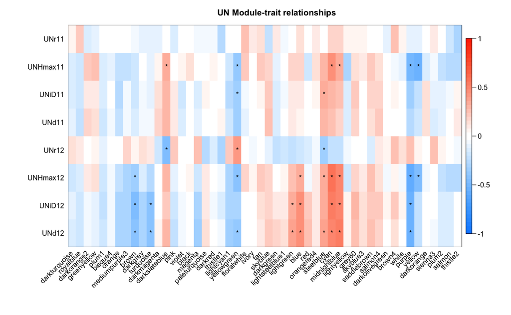

```r
par(mar = c(8, 8, 3, 3));
# Display the correlation values within a heatmap plot
labeledHeatmap(Matrix = blups.cor,
               yLabels = names(blups.UN)[-1],
               xLabels = names(MEs) %>% str_replace("^ME",""),
               xSymbols = names(MEs),
               colorLabels = FALSE,
               colors = blueWhiteRed(50),
               textMatrix = p.asterisk,
               setStdMargins = FALSE,
               #cex.text = 0.5,
               zlim = c(-1,1),
               main = paste("UN Module-trait relationships"))
dev.off()
```

Arbitrary, but let’s take the max and min for each trait (so long as they are significant)

```r
blups.cor.5 <- blups.cor.sig
cor.top <- t(apply(blups.cor.5,1,function(x) {
  maxx = max(x,na.rm=TRUE)
  minx = min(x,na.rm=TRUE)
  ifelse(x == maxx | x == minx, x, NA)
}
))
```

```
no non-missing arguments to max; returning -Infno non-missing arguments to min; returning Infno non-missing arguments to max; returning -Infno non-missing arguments to min; returning Inf
```

```r
cor.top <- cor.top[,apply(cor.top,2,function(x) !all(is.na(x)))]
cor.top
```

```
         MEdarkslateblue MEyellowgreen MEsteelblue    MEcyan MEmidnightblue
UNr11                 NA            NA          NA        NA             NA
UNHmax11              NA            NA          NA 0.4756141             NA
UNiD11                NA    -0.3490175   0.3424031        NA             NA
UNd11                 NA            NA          NA        NA             NA
UNr12         -0.4676983     0.4368051          NA        NA             NA
UNHmax12              NA            NA          NA 0.5768170             NA
UNiD12                NA            NA          NA 0.5225850             NA
UNd12                 NA            NA          NA        NA      0.5251662
           MEpurple   MEyellow
UNr11            NA         NA
UNHmax11         NA -0.5233454
UNiD11           NA         NA
UNd11            NA         NA
UNr12            NA         NA
UNHmax12 -0.5937518         NA
UNiD12   -0.5407645         NA
UNd12    -0.5338425         NA
```

```r
write.csv(cor.top,"../output/Eigen_trait_cor_UN_.5_threshold_all.csv")
```

write the significant Eigen genes

```r
head(MEs[,colnames(blups.cor.sig)])
```

|  | MEbrown | MEturquoise | MEdarkslateblue | MEyellowgreen | MElightgreen | MEblue | MEsteelblue | MEcyan | MEmidnightblue | MEpurple | MEyellow |
| --- | --- | --- | --- | --- | --- | --- | --- | --- | --- | --- | --- |
| RIL_1 | 0.02165880 | 0.05060017 | -0.098414486 | -0.05555577 | 0.18051857 | 0.009731402 | 0.11193145 | -0.01195427 | 0.121505672 | 0.04989082 | 0.07281887 |
| RIL_103 | 0.05515722 | 0.15643611 | 0.049275416 | 0.07449990 | -0.01600263 | -0.132115125 | -0.07569270 | 0.02346493 | -0.010462725 | 0.00563117 | -0.13242446 |
| RIL_104 | -0.08338866 | -0.17831827 | 0.108807859 | -0.04102568 | 0.10099411 | 0.155593102 | -0.06823198 | 0.08272540 | -0.005597987 | -0.21370789 | -0.18546278 |
| RIL_113 | 0.06891831 | 0.10112030 | 0.093176504 | -0.11937279 | -0.11811841 | -0.091659605 | 0.11841440 | -0.06544427 | -0.125114114 | 0.06379898 | 0.07865148 |
| RIL_115 | -0.08615459 | -0.18186808 | 0.001501158 | 0.09760817 | 0.10174250 | 0.130094057 | -0.09371202 | 0.03511877 | -0.027393636 | -0.04371600 | 0.07444985 |
| RIL_12 | -0.02025714 | -0.01859692 | -0.117484469 | 0.10407953 | 0.07451211 | -0.016239278 | -0.10236860 | -0.11844280 | -0.019195316 | 0.10332750 | 0.13324049 |

```r
write.csv(MEs[,colnames(blups.cor.sig)],"../output/Sig_Eigen_genes_UN_all.csv")
```

write all Eigen genes

```r
write.csv(MEs,"../output/All_Eigen_genes_UN_all.csv")
```

save WGCNA info

```r
save(annotation,blups.cor,blups.cor.5,blups.cor.P,blups.cor.sig,moduleColors,MEs,merge,expr.data.UN.t,
     file="../output/WGCNA_UN_all.Rdata")
```

## 2012 only

```r
#load("../output/WGCNA_UN_all.Rdata")
ME.blups <- blups.UN %>% select("Line", ends_with("12")) %>% merge(MEs,by.x=1.,by.y=0)
head(ME.blups)
```

|  | Line | UNr12 | UNHmax12 | UNiD12 | UNd12 | MEdarkturquoise | MEroyalblue | MEdarkorange2 | MEgreenyellow | MEplum1 | MEbisque4 | MEorange | MEmediumpurple3 | MEbrown | MEdarkgrey | MEturquoise | MEdarkmagenta | MEdarkslateblue | MEpink | MEviolet | MEblack | MEmagenta | MEpaleturquoise | MEdarkred | MEthistle1 | MElightcyan1 | MEyellowgreen | MEfloralwhite | MEivory | … |
| --- | --- | --- | --- | --- | --- | --- | --- | --- | --- | --- | --- | --- | --- | --- | --- | --- | --- | --- | --- | --- | --- | --- | --- | --- | --- | --- | --- | --- | --- | --- |
| 1 | RIL_1 | 0.01265305 | 40.07475 | 659.1968 | 944.3922 | -0.10946134 | 0.11076526 | -0.09466035 | -0.09078331 | -0.02290192 | -0.13375851 | 0.02955794 | -0.02039907 | 0.02165880 | 0.03167984 | 0.05060017 | -0.10440873 | -0.098414486 | -0.11239540 | 0.110902510 | 0.061152155 | 0.010755965 | 0.09702839 | 0.08270291 | -0.06880387 | -0.10622587 | -0.05555577 | 0.10507580 | 0.09393829 | … |
| 2 | RIL_103 | 0.01411398 | 46.96119 | 617.6269 | 870.6890 | -0.09812739 | -0.03139994 | 0.09956483 | 0.08971814 | 0.08086269 | 0.08320402 | 0.07900311 | 0.03297917 | 0.05515722 | 0.12861012 | 0.15643611 | 0.10392982 | 0.049275416 | -0.13314164 | -0.054298276 | -0.001094512 | 0.025694326 | -0.10877784 | 0.09030576 | -0.10349462 | 0.07167806 | 0.07449990 | 0.09596312 | 0.10408453 | … |
| 3 | RIL_115 | 0.01350071 | 26.29595 | 652.5562 | 910.2024 | 0.08641094 | 0.11558657 | -0.08882880 | -0.07863761 | -0.11167213 | -0.05125664 | -0.13324894 | -0.07455847 | -0.08615459 | -0.12732856 | -0.18186808 | 0.11070238 | 0.001501158 | -0.10620917 | 0.020639294 | 0.002415041 | -0.057466514 | 0.14681329 | 0.10573861 | -0.07377138 | 0.07890335 | 0.09760817 | -0.07952442 | -0.11390334 | … |
| 4 | RIL_12 | 0.01447632 | 19.86868 | 516.6281 | 762.5616 | 0.10950964 | 0.13294756 | 0.10203578 | -0.08308081 | -0.13505667 | -0.11583528 | -0.13160553 | -0.08475282 | -0.02025714 | 0.02418190 | -0.01859692 | -0.07095040 | -0.117484469 | 0.09452768 | -0.085701311 | 0.043966674 | 0.085575559 | -0.08455629 | 0.07440607 | -0.08892758 | 0.06932473 | 0.10407953 | 0.08666821 | 0.08982628 | … |
| 5 | RIL_124 | 0.01195275 | 44.69516 | 695.4424 | 966.1398 | -0.08807011 | 0.07338637 | 0.09703610 | 0.11306634 | -0.08409589 | 0.09840015 | 0.07452152 | 0.11616136 | -0.04467512 | 0.05904689 | 0.04643403 | 0.10847883 | 0.079556780 | 0.06627845 | 0.005876234 | -0.055826864 | -0.004667133 | -0.08861028 | 0.03938156 | -0.09306848 | -0.11446662 | -0.11614309 | -0.09133880 | -0.10543975 | … |
| 6 | RIL_131 | 0.01375755 | 27.99045 | 487.2746 | 750.1288 | 0.03144206 | -0.09173727 | -0.09425883 | -0.09422212 | 0.09444277 | -0.06377024 | 0.07263697 | 0.10386224 | 0.10547322 | 0.09986918 | 0.14435026 | -0.08662093 | 0.003424444 | -0.12744100 | -0.007726053 | -0.067740689 | -0.016041716 | -0.02917485 | -0.07654533 | 0.09881215 | -0.12047825 | -0.11290895 | 0.09139788 | 0.11328518 | … |

```r
blups.cor <- cor(select(ME.blups,starts_with("UN")),
                 select(ME.blups, starts_with("ME")))
range(blups.cor)
```

```
[1] -0.5937518  0.5768170
```

```r
blups.cor
```

```
         MEdarkturquoise MEroyalblue MEdarkorange2 MEgreenyellow     MEplum1
UNr12         0.15690997   0.1001269   -0.03149390    0.07349787 -0.09967295
UNHmax12     -0.17798772  -0.1335870    0.10793901    0.14350248 -0.17148438
UNiD12       -0.09119076  -0.1674328   -0.04464388   -0.08067054 -0.22668319
UNd12        -0.12941698  -0.1823899   -0.04048194   -0.09929924 -0.18922322
           MEbisque4    MEorange MEmediumpurple3     MEbrown MEdarkgrey MEturquoise
UNr12     0.03067204  0.00698962       0.1764247  0.06158113  0.1416815   0.1093089
UNHmax12 -0.05398305 -0.23432269      -0.2919372 -0.34732105 -0.1517913  -0.2500351
UNiD12   -0.04383733 -0.31874137      -0.2920270 -0.47274885 -0.3052421  -0.4142078
UNd12    -0.04203595 -0.28724024      -0.3046223 -0.43433434 -0.3195442  -0.4012833
         MEdarkmagenta MEdarkslateblue     MEpink     MEviolet      MEblack
UNr12      -0.17020187      -0.4676983  0.2100307  0.019345950  0.002965096
UNHmax12   -0.00334921       0.3111767 -0.1146356  0.002102611  0.075578760
UNiD12      0.02473889       0.2390084 -0.1876557 -0.075056424  0.002645095
UNd12       0.06067140       0.3104783 -0.2318856 -0.068511962 -0.009671527
          MEmagenta MEpaleturquoise   MEdarkred  MEthistle1 MElightcyan1
UNr12     0.2536431      -0.2496897 -0.13798913 -0.30211467    0.2148695
UNHmax12 -0.1708652       0.1068081  0.03756275 -0.06196605   -0.2850065
UNiD12   -0.2918784       0.1117207 -0.05347108 -0.14675202   -0.3032743
UNd12    -0.3295595       0.1568658 -0.02439626 -0.06428696   -0.3270365
         MEyellowgreen MEfloralwhite      MEivory      MEtan   MEskyblue
UNr12        0.4368051    0.03565202 -0.070825033 0.00859107 -0.09870698
UNHmax12    -0.4023238    0.19640424  0.075789337 0.22271792  0.16118516
UNiD12      -0.3029877   -0.02117744 -0.039560766 0.12661435  0.19366215
UNd12       -0.3635991   -0.02477776 -0.002990699 0.11268684  0.20525354
          MEdarkgreen MElightsteelblue1 MElightgreen     MEblue       MEred
UNr12    -0.202724807       -0.19491050   -0.2346440 -0.1641064 -0.15387921
UNHmax12 -0.003061359        0.06823245    0.2764831  0.3418758 -0.04780658
UNiD12    0.115410700        0.09924395    0.3532366  0.4768825  0.22973062
UNd12     0.166371982        0.13922940    0.3762556  0.4730140  0.24952979
         MEorangered4 MEsteelblue     MEcyan MEmidnightblue MElightyellow
UNr12     -0.05770039  -0.3460067 -0.2056323     -0.2243424   -0.07268613
UNHmax12   0.10507934   0.3540780  0.5768170      0.5125199   -0.18588071
UNiD12     0.09534333   0.3368878  0.5225850      0.5197314    0.05545514
UNd12      0.09081861   0.3859504  0.5143309      0.5251662    0.07806637
            MEgrey60  MEskyblue3 MEsaddlebrown MEsalmon4 MEdarkolivegreen
UNr12    0.006448866 -0.01455325    -0.1421218 0.1077510       0.07686062
UNHmax12 0.185967492  0.11824868     0.2623710 0.1553618      -0.04908955
UNiD12   0.292255669  0.15631592     0.2213855 0.2268931       0.04527191
UNd12    0.258776462  0.14639276     0.2463992 0.1838330       0.00674445
           MEbrown4     MEwhite   MEpurple    MEyellow MEdarkorange   MEsienna3
UNr12    0.25696334  0.13095911  0.2449477  0.06592048  -0.01671846  0.24955226
UNHmax12 0.07328057 -0.05460900 -0.5937518 -0.47950254  -0.06512736  0.01925657
UNiD12   0.20876146  0.06776774 -0.5407645 -0.22921336   0.03613718 -0.01395401
UNd12    0.13381772  0.03770212 -0.5338425 -0.21416073   0.03323128 -0.06804294
             MEplum2     MEsalmon   MEthistle2
UNr12     0.05822217 -0.005656349 -0.069148035
UNHmax12 -0.22890555 -0.270233531 -0.242024307
UNiD12   -0.14224973 -0.146332746 -0.001806667
UNd12    -0.13866929 -0.131507675  0.012042293
```

```r
blups.cor.P <- corPvalueStudent(blups.cor,nrow(expr.data.UN.t)) %>%
  p.adjust() %>% #using "holm" method.  For relaxed stringency could use "fdr"
  matrix(nrow=nrow(blups.cor),
         dimnames = dimnames(blups.cor))
sum(blups.cor.P < 0.05)
```

```
[1] 30
```

```r
blups.cor.sig <- blups.cor
blups.cor.sig[blups.cor.P>0.05] <- NA
blups.cor.sig <- blups.cor.sig[,!apply(blups.cor.sig,2,function(x) all(is.na(x)))]
blups.cor.sig
```

```
            MEbrown MEturquoise MEdarkslateblue  MEmagenta MElightcyan1
UNr12            NA          NA      -0.4676983         NA           NA
UNHmax12 -0.3473210          NA              NA         NA           NA
UNiD12   -0.4727488  -0.4142078              NA         NA           NA
UNd12    -0.4343343  -0.4012833              NA -0.3295595   -0.3270365
         MEyellowgreen MElightgreen    MEblue MEsteelblue    MEcyan MEmidnightblue
UNr12        0.4368051           NA        NA  -0.3460067        NA             NA
UNHmax12    -0.4023238           NA 0.3418758   0.3540780 0.5768170      0.5125199
UNiD12              NA    0.3532366 0.4768825   0.3368878 0.5225850      0.5197314
UNd12       -0.3635991    0.3762556 0.4730140   0.3859504 0.5143309      0.5251662
           MEpurple   MEyellow
UNr12            NA         NA
UNHmax12 -0.5937518 -0.4795025
UNiD12   -0.5407645         NA
UNd12    -0.5338425         NA
```

```r
p.asterisk <- ifelse(blups.cor.P < 0.05, "*","")
```

plot it

```r
# Will display correlations and their p-values
par(mar = c(8, 8, 3, 3));
# Display the correlation values within a heatmap plot
labeledHeatmap(Matrix = blups.cor,
               yLabels = rownames(blups.cor),
               xLabels = names(MEs),
               xSymbols = names(MEs) %>% str_replace("^ME",""),
               xColorLabels = TRUE,
               colors = blueWhiteRed(50),
               textMatrix = p.asterisk,
               setStdMargins = FALSE,
               #cex.text = 0.5,
               zlim = c(-1,1),
               main = "UN Module-trait relationships")
pdf("../output/Module-trait_heatmap_UN_2012.pdf",height = 4,width = 12)
```

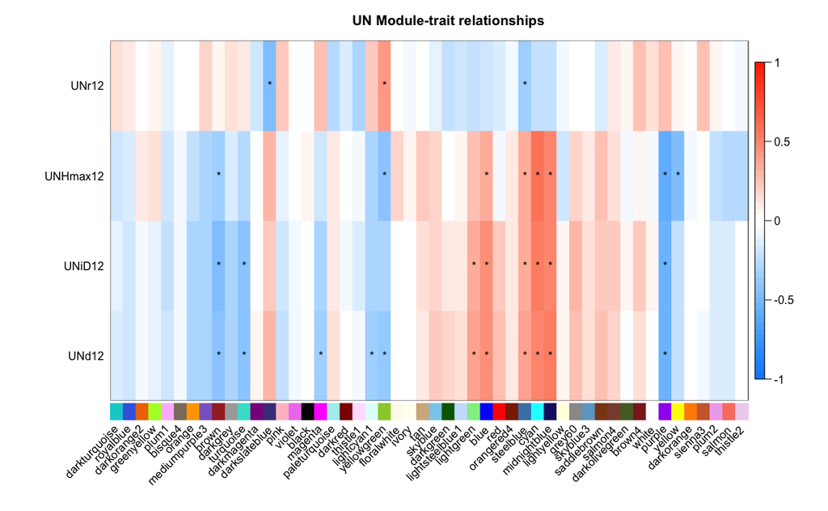

```r
par(mar = c(8, 8, 3, 3));
# Display the correlation values within a heatmap plot
labeledHeatmap(Matrix = blups.cor,
               yLabels = rownames(blups.cor),
               xLabels = names(MEs),
               xSymbols = names(MEs) %>% str_replace("^ME",""),
               XcolorLabels = FALSE,
               colors = blueWhiteRed(50),
               textMatrix = p.asterisk,
               setStdMargins = FALSE,
               #cex.text = 0.5,
               zlim = c(-1,1),
               main = paste("UN Module-trait relationships"))
dev.off()
```

Arbitrary, but let’s take the max and min for each trait (so long as they are significant)

```r
blups.cor.5 <- blups.cor.sig
cor.top <- t(apply(blups.cor.5,1,function(x) {
  maxx = max(x,na.rm=TRUE)
  minx = min(x,na.rm=TRUE)
  ifelse(x == maxx | x == minx, x, NA)
}
))
cor.top <- cor.top[,apply(cor.top,2,function(x) !all(is.na(x)))]
cor.top
```

```
         MEdarkslateblue MEyellowgreen   MEcyan MEmidnightblue   MEpurple
UNr12         -0.4676983     0.4368051       NA             NA         NA
UNHmax12              NA            NA 0.576817             NA -0.5937518
UNiD12                NA            NA 0.522585             NA -0.5407645
UNd12                 NA            NA       NA      0.5251662 -0.5338425
```

```r
write.csv(cor.top,"../output/Eigen_trait_cor_UN_.5_threshold_2012.csv")
```

write the significant Eigen genes

```r
head(MEs[,colnames(blups.cor.sig)])
```

|  | MEbrown | MEturquoise | MEdarkslateblue | MEmagenta | MElightcyan1 | MEyellowgreen | MElightgreen | MEblue | MEsteelblue | MEcyan | MEmidnightblue | MEpurple | MEyellow |
| --- | --- | --- | --- | --- | --- | --- | --- | --- | --- | --- | --- | --- | --- |
| RIL_1 | 0.02165880 | 0.05060017 | -0.098414486 | 0.01075597 | -0.10622587 | -0.05555577 | 0.18051857 | 0.009731402 | 0.11193145 | -0.01195427 | 0.121505672 | 0.04989082 | 0.07281887 |
| RIL_103 | 0.05515722 | 0.15643611 | 0.049275416 | 0.02569433 | 0.07167806 | 0.07449990 | -0.01600263 | -0.132115125 | -0.07569270 | 0.02346493 | -0.010462725 | 0.00563117 | -0.13242446 |
| RIL_104 | -0.08338866 | -0.17831827 | 0.108807859 | -0.02244248 | 0.08252449 | -0.04102568 | 0.10099411 | 0.155593102 | -0.06823198 | 0.08272540 | -0.005597987 | -0.21370789 | -0.18546278 |
| RIL_113 | 0.06891831 | 0.10112030 | 0.093176504 | -0.02521756 | -0.13173627 | -0.11937279 | -0.11811841 | -0.091659605 | 0.11841440 | -0.06544427 | -0.125114114 | 0.06379898 | 0.07865148 |
| RIL_115 | -0.08615459 | -0.18186808 | 0.001501158 | -0.05746651 | 0.07890335 | 0.09760817 | 0.10174250 | 0.130094057 | -0.09371202 | 0.03511877 | -0.027393636 | -0.04371600 | 0.07444985 |
| RIL_12 | -0.02025714 | -0.01859692 | -0.117484469 | 0.08557556 | 0.06932473 | 0.10407953 | 0.07451211 | -0.016239278 | -0.10236860 | -0.11844280 | -0.019195316 | 0.10332750 | 0.13324049 |

```r
write.csv(MEs[,colnames(blups.cor.sig)],"../output/Sig_Eigen_genes_UN_2012.csv")
```

write all Eigen genes

```r
write.csv(MEs,"../output/All_Eigen_genes_UN_2012.csv")
```

save WGCNA info

```r
save(annotation,blups.cor,blups.cor.5,blups.cor.P,blups.cor.sig,moduleColors,MEs,merge,expr.data.UN.t,
     file="../output/WGCNA_UN_2012.Rdata")
```

## GO enrichment for each signficant cluster

```r
load("../output/WGCNA_UN_2012.Rdata")
module_genes <- tibble(GeneID=colnames(expr.data.UN.t), module=moduleColors)
module_genes
```

| GeneID | module |
| --- | --- |
| Bra016271 | darkgrey |
| Bra038030 | steelblue |
| Bra040132 | floralwhite |
| Bra017243 | skyblue |
| Bra032770 | royalblue |
| Bra040221 | floralwhite |
| Bra017966 | lightyellow |
| Bra030455 | royalblue |
| Bra021166 | salmon |
| Bra002785 | lightgreen |

[output cut: 990 more lines]

Get GO list and gene lengths

```r
cd ../input
wget http://www.g3journal.org/content/suppl/2014/08/12/g3.114.012526.DC1/FileS11.txt
wget http://jnmaloof.github.io/BIS180L_web/data/Brapa_CDS_lengths.txt
```

```r
library(goseq)
library(tidyverse)
library(stringr)
```

Format data for GOseq

```r
module_genes <- semi_join(module_genes,gene.lengths.module)
```

Format go.terms for goseq. We want them in list format, and we need to separate the terms into separate elements.

```r
go.list <- strsplit(go.terms$GO,split=",")
names(go.list) <- go.terms$GeneID
head(go.list)
```

```
$Bra002000
[1] "GO:0005488"

$Bra001201
[1] "GO:0000160" "GO:0009927" "GO:0000155" "GO:0018106" "GO:0005524" "GO:0004740"
[7] "GO:0005739"

$Bra001122
[1] "GO:0050832" "GO:0016023" "GO:0008061" "GO:0042742"

$Bra001115
[1] "GO:0009825" "GO:0001578" "GO:0055028" "GO:0007163" "GO:0010031" "GO:0010015"
[7] "GO:0010091"

$Bra001108
[1] "GO:0000166" "GO:0003723"

$Bra001050
[1] "GO:0070628" "GO:0043130" "GO:0005634"
```

Now we will loop through each significant module

First, get the sig modules

```r
sig.modules <- colnames(blups.cor.P) %>%
  magrittr::extract(apply(blups.cor.P,2,function(x) any(x < 0.05))) %>%
  str_replace("ME","")
sig.modules
```

```
 [1] "brown"         "turquoise"     "darkslateblue" "magenta"       "lightcyan1"
 [6] "yellowgreen"   "lightgreen"    "blue"          "steelblue"     "cyan"
[11] "midnightblue"  "purple"        "yellow"
```

Format module data for goseq. We need a vector for each gene with 1 indicating module membership and 0 indicating not in module

```r
file.remove("../output/SupTable_JM5_WGCNA_UN_GO_2012.csv")
```

```
[1] TRUE
```

```r
GO.results <- lapply(sig.modules, function(module) {
  module01 <- module_genes$module %>% str_detect(module) %>% as.numeric()
  names(module01) <- module_genes$GeneID

  #determines if there is bias due to gene length.
  nullp.result.tmp <- nullp(DEgenes = module01,bias.data = gene.lengths.vector,plot.fit = FALSE)

  #calculate p-values for each GO term
  GO.out.tmp <- goseq(pwf = nullp.result.tmp,gene2cat = go.list,test.cats=("GO:BP"))

  #Keep BP only
  GO.out.tmp <- GO.out.tmp[GO.out.tmp$ontology=="BP",]

  #Calculate FDR
  GO.out.tmp <- GO.out.tmp %>% as.tibble() %>%
    mutate(FDR=p.adjust(over_represented_pvalue, method = "fdr"),module=module) %>%
    filter(FDR < 0.05) %>%
    select(module,term,ontology,FDR,over_represented_pvalue,everything())

  write_csv(GO.out.tmp,path = "../output/SupTable_JM5_WGCNA_UN_GO_2012.csv",append = TRUE)

  GO.out.tmp
})
```

[output not shown]

[output cut: 10 more lines]

[output not shown]

```r
names(GO.results) <- sig.modules
```

```r
GO.results
```

| module | term | ontology | FDR | over_represented_pvalue | category | under_represented_pvalue | numDEInCat | numInCat |
| --- | --- | --- | --- | --- | --- | --- | --- | --- |
| brown | actin cytoskeleton organization | BP | 0.0009658657 | 5.602469e-07 | GO:0030036 | 1.0000000 | 9 | 13 |
| brown | protein dephosphorylation | BP | 0.0024318446 | 2.821165e-06 | GO:0006470 | 0.9999995 | 15 | 39 |

| module | term | ontology | FDR | over_represented_pvalue | category | under_represented_pvalue | numDEInCat | numInCat |
| --- | --- | --- | --- | --- | --- | --- | --- | --- |
| turquoise | intracellular protein transport | BP | 0.01211729 | 7.028592e-06 | GO:0006886 | 0.999998 | 29 | 64 |

| module | term | ontology | FDR | over_represented_pvalue | category | under_represented_pvalue | numDEInCat | numInCat |
| --- | --- | --- | --- | --- | --- | --- | --- | --- |

| module | term | ontology | FDR | over_represented_pvalue | category | under_represented_pvalue | numDEInCat | numInCat |
| --- | --- | --- | --- | --- | --- | --- | --- | --- |

| module | term | ontology | FDR | over_represented_pvalue | category | under_represented_pvalue | numDEInCat | numInCat |
| --- | --- | --- | --- | --- | --- | --- | --- | --- |

| module | term | ontology | FDR | over_represented_pvalue | category | under_represented_pvalue | numDEInCat | numInCat |
| --- | --- | --- | --- | --- | --- | --- | --- | --- |

| module | term | ontology | FDR | over_represented_pvalue | category | under_represented_pvalue | numDEInCat | numInCat |
| --- | --- | --- | --- | --- | --- | --- | --- | --- |

| module | term | ontology | FDR | over_represented_pvalue | category | under_represented_pvalue | numDEInCat | numInCat |
| --- | --- | --- | --- | --- | --- | --- | --- | --- |
| blue | cell division | BP | 0.0000954929 | 5.539032e-08 | GO:0051301 | 1.0000000 | 26 | 42 |
| blue | nucleosome assembly | BP | 0.0002303467 | 2.672235e-07 | GO:0006334 | 1.0000000 | 17 | 23 |
| blue | microtubule-based movement | BP | 0.0020579186 | 3.581065e-06 | GO:0007018 | 0.9999991 | 26 | 49 |
| blue | auxin metabolic process | BP | 0.0045604311 | 1.319507e-05 | GO:0009850 | 0.9999996 | 9 | 10 |
| blue | regulation of meristem structural organization | BP | 0.0045604311 | 1.322631e-05 | GO:0009934 | 0.9999996 | 9 | 10 |
| blue | leaf development | BP | 0.0054352322 | 1.891612e-05 | GO:0048366 | 0.9999953 | 23 | 44 |
| blue | xylem and phloem pattern formation | BP | 0.0257111983 | 1.140480e-04 | GO:0010051 | 0.9999865 | 11 | 16 |
| blue | microtubule nucleation | BP | 0.0257111983 | 1.367503e-04 | GO:0007020 | 1.0000000 | 6 | 6 |
| blue | positive regulation of microtubule polymerization | BP | 0.0257111983 | 1.367503e-04 | GO:0031116 | 1.0000000 | 6 | 6 |
| blue | regulation of cell cycle | BP | 0.0257111983 | 1.491369e-04 | GO:0051726 | 0.9999579 | 21 | 43 |

[output cut: 3 more lines]

| module | term | ontology | FDR | over_represented_pvalue | category | under_represented_pvalue | numDEInCat | numInCat |
| --- | --- | --- | --- | --- | --- | --- | --- | --- |

| module | term | ontology | FDR | over_represented_pvalue | category | under_represented_pvalue | numDEInCat | numInCat |
| --- | --- | --- | --- | --- | --- | --- | --- | --- |
| cyan | translation | BP | 1.875931e-48 | 1.088127e-51 | GO:0006412 | 1 | 52 | 145 |
| cyan | ribosome biogenesis | BP | 1.295325e-16 | 1.502698e-19 | GO:0042254 | 1 | 19 | 51 |

| module | term | ontology | FDR | over_represented_pvalue | category | under_represented_pvalue | numDEInCat | numInCat |
| --- | --- | --- | --- | --- | --- | --- | --- | --- |
| midnightblue | toxin catabolic process | BP | 3.477076e-05 | 2.016865e-08 | GO:0009407 | 1.0000000 | 7 | 20 |
| midnightblue | response to wounding | BP | 6.238366e-05 | 7.237083e-08 | GO:0009611 | 1.0000000 | 13 | 117 |
| midnightblue | sulfate assimilation | BP | 1.353138e-04 | 2.354648e-07 | GO:0000103 | 1.0000000 | 6 | 17 |
| midnightblue | glucosinolate biosynthetic process | BP | 1.988544e-03 | 4.613791e-06 | GO:0019761 | 0.9999999 | 5 | 16 |
| midnightblue | regulation of response to red or far red light | BP | 5.018477e-03 | 1.455475e-05 | GO:2000030 | 0.9999997 | 4 | 10 |
| midnightblue | male gamete generation | BP | 5.592672e-03 | 1.946405e-05 | GO:0048232 | 0.9999999 | 3 | 4 |
| midnightblue | response to cadmium ion | BP | 9.107019e-03 | 4.245479e-05 | GO:0046686 | 0.9999886 | 17 | 333 |
| midnightblue | post-embryonic root development | BP | 9.107019e-03 | 4.531932e-05 | GO:0048528 | 0.9999996 | 3 | 5 |
| midnightblue | glucosinolate catabolic process | BP | 9.107019e-03 | 4.754244e-05 | GO:0019762 | 0.9999996 | 3 | 5 |
| midnightblue | response to jasmonic acid | BP | 1.068546e-02 | 6.198062e-05 | GO:0009753 | 0.9999919 | 8 | 81 |

[output cut: 11 more lines]

| module | term | ontology | FDR | over_represented_pvalue | category | under_represented_pvalue | numDEInCat | numInCat |
| --- | --- | --- | --- | --- | --- | --- | --- | --- |

| module | term | ontology | FDR | over_represented_pvalue | category | under_represented_pvalue | numDEInCat | numInCat |
| --- | --- | --- | --- | --- | --- | --- | --- | --- |
| yellow | oxidation-reduction process | BP | 8.656336e-05 | 5.021077e-08 | GO:0055114 | 1.0000000 | 90 | 518 |
| yellow | response to light stimulus | BP | 1.048069e-04 | 1.215857e-07 | GO:0009416 | 1.0000000 | 24 | 74 |
| yellow | response to cold | BP | 6.070669e-04 | 1.056381e-06 | GO:0009409 | 0.9999996 | 37 | 161 |
| yellow | photosynthetic electron transport in photosystem I | BP | 2.663958e-03 | 6.525081e-06 | GO:0009773 | 0.9999999 | 6 | 7 |
| yellow | response to symbiotic fungus | BP | 2.663958e-03 | 9.271314e-06 | GO:0009610 | 0.9999996 | 7 | 10 |
| yellow | photosynthetic electron transport chain | BP | 2.663958e-03 | 9.271314e-06 | GO:0009767 | 0.9999996 | 7 | 10 |
| yellow | reductive pentose-phosphate cycle | BP | 5.236191e-03 | 2.386140e-05 | GO:0019253 | 0.9999993 | 6 | 8 |
| yellow | photorespiration | BP | 5.236191e-03 | 2.429787e-05 | GO:0009853 | 0.9999976 | 9 | 18 |

```
NA
```

## Are any of the clusters due to linkage?

```r
BrapaLocation <- read_csv("../input/Brapa_V1.5_annotated.csv") %>% select(GeneID=name, chrom, start)
BrapaLocation
```

```r
modules_genes.pl <- left_join(module_genes, BrapaLocation)
modules_genes.pl %>%
  filter(module %in% sig.modules, str_detect(chrom,"^A[01]")) %>%
  ggplot(aes(x=start)) +
  geom_dotplot() +
  facet_grid(module ~ chrom) +
  theme(axis.text.x = element_text(angle = 90),
        strip.text.y = element_text(angle=0))
ggsave("../output/WGCNA_2012_UN_module_by_chromosome.pdf")
```

[output not shown]